# examples_future

### Graph 3

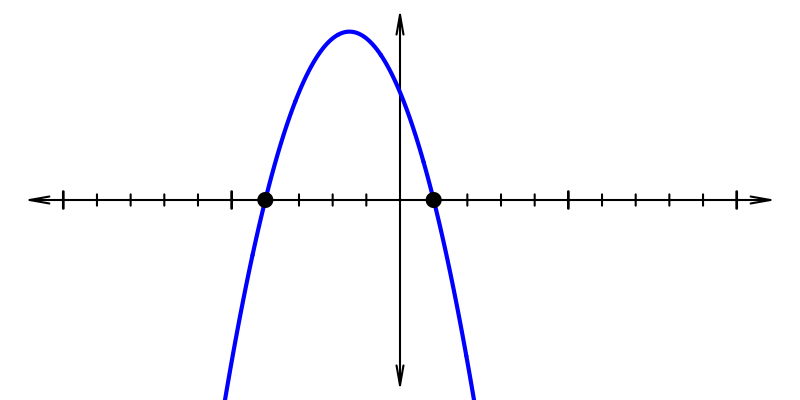

Which function matches Graph 3?

- $A(x)~=~(x-1)^{2}(x-4)$
- $B(x)~=~-(x-1)(x+4)$
- $C(x)~=~-(x+1)(x+4)$
- $D(x)~=~-(x+1)^{2}(x+4)$
- Graph 1 is $A(x)~=~(x-3)(x-7)$
- Graph 2 is $A(x)~=~(x-5)^{2}(x-8)$
- Graph 3 is $B(x)~=~-(x-1)(x+4)$

Remember, each factor is $(x-r)$ where $r$ is the root. If the factor is squared, we expect a bounce. Lastly, make sure to pay attention to the sign in front, which will dictate the end behavior.

### Graph 1

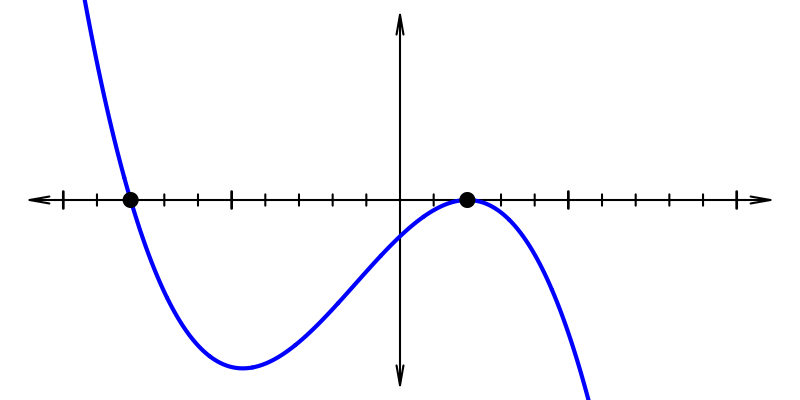

Which function matches Graph 1?

- $A(x)~=~-(x-2)(x-8)^{2}$
- $B(x)~=~-(x-2)^{2}(x+8)$
- $C(x)~=~-(x+2)(x-8)$
- $D(x)~=~(x+2)(x+8)$

### Graph 2

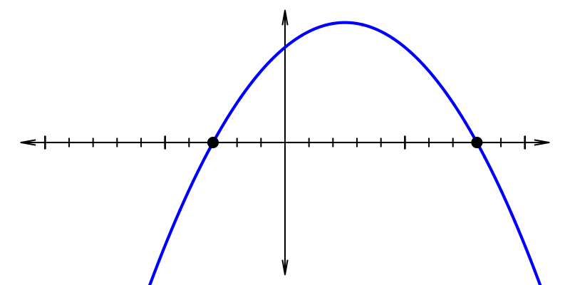

Which function matches Graph 2?

- $A(x)~=~-(x-3)(x-8)^{2}$
- $B(x)~=~-(x-3)(x+8)^{2}$
- $C(x)~=~-(x+3)(x-8)$
- $D(x)~=~(x+3)(x-8)$

### Graph 3

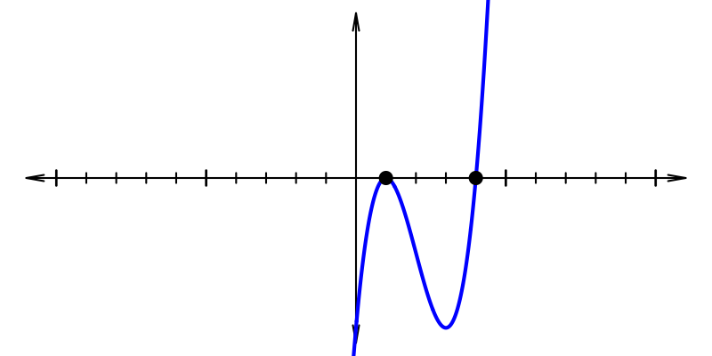

Which function matches Graph 3?

- $A(x)~=~(x-1)^{2}(x-4)$
- $B(x)~=~-(x-1)^{2}(x-4)^{2}$
- $C(x)~=~(x-1)(x+4)^{2}$
- $D(x)~=~(x+1)(x+4)^{2}$
- Graph 1 is $B(x)~=~-(x-2)^{2}(x+8)$
- Graph 2 is $C(x)~=~-(x+3)(x-8)$
- Graph 3 is $A(x)~=~(x-1)^{2}(x-4)$

Remember, each factor is $(x-r)$ where $r$ is the root. If the factor is squared, we expect a bounce. Lastly, make sure to pay attention to the sign in front, which will dictate the end behavior.